# From {icio} to {ddec}: transition report

Work done so far on turning the GVC package into a demographic-decomposition package

Published

November 18, 2026

## Summary

`ddec` started as a fork of `icio` 1.0.0, an R package of four global value chain (GVC) decompositions of inter-country input-output tables. It is now `ddec` 0.1.0, titled *Demographic Decomposition Methods*. It contains:

- the four GVC decompositions, **unchanged**;
- **seven demographic decomposition methods**, written from scratch and checked against the reference packages: Kitagawa, Das Gupta, Arriaga, stepwise replacement, Horiuchi, fixed-design LTRE, and a generic Shapley decomposition;
- a **bridging layer** showing that the two fields share their machinery: the Leontief inverse is the fundamental matrix of an absorbing Markov chain, and LTRE and Leontief attribution are the same “sensitivity × change” operation;
- real Danish mortality data, a synthetic ICIO data generator, a Quarto report in `analysis/`, `renv`, and a reference list checked against Crossref.

| Branch | `init-claude`, two commits on top of `master` (`cc96859`, `e29d7df`); not pushed |
| --- | --- |
| Size of change | 103 files, +11,092 / −368 lines; 32 files and +1,752 lines in `R/` and `tests/` |
| Tests | 382 expectations, 0 failures, 0 skipped (cross-checks included) |
| `R CMD check` | 0 errors, 0 warnings, 0 notes |
| Report | `quarto render` builds `analysis/` from a clean state with no network access |

## Starting point and approach

`icio` is a single-purpose GVC package. Its core is `load_icio()`, which computes the Leontief inverse $B = (I - A)^{-1}$ once, plus `bm()`, `leontief()`, `kww()` and `wwz()`, which decompose gross exports. It is fast because it uses matrixStats, data.table and a small C routine throughout. The project brief (`ddec-jump-start.md`) asked for a package and Quarto report that demonstrate the overlap between GVC and demographic decompositions.

The guiding decisions were:

- **Keep the GVC engines verbatim.** They are tested against Stata `icio` and GlobalValueChains.jl, so they were renamed into the new package rather than rewritten. The ICIO object keeps its class name `"icio"`: it names the object type, not the package.
- **No dependency on `icio`, and no compatibility shims.** This repository *is* `icio`, so importing it would be circular.
- **Write the demographic methods from scratch, and verify them against the reference implementations** (DasGuptR, LEdecomp, DemoDecomp, popbio) at 1e-6 or better. Those packages are in Suggests, not Imports.
- **Make speed come from vectorising `func`.** In the generic decompositions almost all of the time is spent evaluating the user’s function, so the speed work targets that (see Performance).

## What was done

### 1. Renaming the package

DESCRIPTION, NAMESPACE, the compiled-code registration (`R_init_ddec`), the package help page, CITATION, pkgdown configuration, README, NEWS, the vignette (`vignettes/gvc.Rmd`), CLAUDE.md and the three GitHub workflows were all updated. CRAN-specific files for `icio` (`cran-comments.md`) were removed. The `icio` NEWS history is kept below the new `ddec 0.1.0` entry.

### 2. Demographic decompositions

```r
data.table(
  Function = c("kitagawa2()", "das_gupta_n()", "life_table()", "life_expectancy()",
               "arriaga_decomp()", "stepwise_decomp()", "horiuchi_decomp()", "ltre_fixed()"),
  Method = c("Rate vs composition effects", "N-factor standardisation", "Period life table",
             "e0, vectorised over matrix columns", "Direct / indirect / interaction by age",
             "Stepwise replacement", "Pseudo-continuous (path integral)", "Fixed-design LTRE"),
  Reference = c("Kitagawa (1955)", "Das Gupta (1993)", "Preston et al. (2001)", "—",
                "Arriaga (1984)", "Andreev, Shkolnikov & Begun (2002)",
                "Horiuchi, Wilmoth & Pletcher (2008)", "Caswell (1989)"),
  `Verified against` = c("DasGuptR (Das Gupta Example 5.1)", "DasGuptR (Example 2.3)",
                         "LEdecomp::mx_to_e0()", "life_table()", "LEdecomp::arriaga()",
                         "DemoDecomp::stepwise_replacement()", "DemoDecomp::horiuchi()",
                         "popbio::LTRE()"))
```

| Function | Method | Reference | Verified against |
| --- | --- | --- | --- |
| kitagawa2() | Rate vs composition effects | Kitagawa (1955) | DasGuptR (Das Gupta Example 5.1) |
| das_gupta_n() | N-factor standardisation | Das Gupta (1993) | DasGuptR (Example 2.3) |
| life_table() | Period life table | Preston et al. (2001) | LEdecomp::mx_to_e0() |
| life_expectancy() | e0, vectorised over matrix columns | — | life_table() |
| arriaga_decomp() | Direct / indirect / interaction by age | Arriaga (1984) | LEdecomp::arriaga() |
| stepwise_decomp() | Stepwise replacement | Andreev, Shkolnikov & Begun (2002) | DemoDecomp::stepwise_replacement() |
| horiuchi_decomp() | Pseudo-continuous (path integral) | Horiuchi, Wilmoth & Pletcher (2008) | DemoDecomp::horiuchi() |
| ltre_fixed() | Fixed-design LTRE | Caswell (1989) | popbio::LTRE() |

References: Kitagawa (1955), Das Gupta (1993), Preston et al. (2001), Arriaga (1984), Andreev et al. (2002), Horiuchi et al. (2008), Caswell (1989).

### 3. Bridging layer

```r
data.table(
  Function = c("leontief_inverse(), fundamental_matrix()", "value_added_multipliers(), expected_time_in_state()",
               "shapley_decomp(), sequential_decomp(), all_orderings()",
               "lambda_sensitivity(), leontief_sensitivity(), numeric_sensitivity()",
               "gvc_components()", "simulate_icio()"),
  Role = c("One internal (I − M)⁻¹ routine powers both: the Leontief inverse is the fundamental matrix",
           "Output multipliers ↔ life expectancy by starting state",
           "Order-free decomposition of any function; the order-dependent alternative; spread over all orderings",
           "∂λ/∂A = v w′/⟨v,w⟩ and ∂(v′Be)/∂A = (v′B)′(Be)′: both outer products",
           "All four GVC methods mapped to common categories (VAX, REF, DDC, FVA, FDC)",
           "Small balanced synthetic ICIO tables"))
```

| Function | Role |
| --- | --- |
| leontief_inverse(), fundamental_matrix() | One internal (I − M)⁻¹ routine powers both: the Leontief inverse is the fundamental matrix |
| value_added_multipliers(), expected_time_in_state() | Output multipliers ↔︎ life expectancy by starting state |
| shapley_decomp(), sequential_decomp(), all_orderings() | Order-free decomposition of any function; the order-dependent alternative; spread over all orderings |
| lambda_sensitivity(), leontief_sensitivity(), numeric_sensitivity() | ∂λ/∂A = v w′/⟨v,w⟩ and ∂(v′Be)/∂A = (v′B)′(Be)′: both outer products |
| gvc_components() | All four GVC methods mapped to common categories (VAX, REF, DDC, FVA, FDC) |
| simulate_icio() | Small balanced synthetic ICIO tables |

### 4. Data

```r
data.table(
  Dataset = c("dk_mortality", "icio_synth", "leather"),
  Content = c("Denmark, both sexes, 2000 & 2019: deaths, mid-year population, mx by single age (0–94, 95+)",
              "Two synthetic 3-country × 2-industry ICIO tables, '2010' and '2020'",
              "3 × 3 example ICIO table (inherited)"),
  Source = c("Eurostat demo_magec + demo_pjan; raw downloads cached in data-raw/cache/",
             "simulate_icio(), data-raw/get_icio_data.R", "icio / decompr"),
  Real = c("yes", "no (synthetic)", "toy"))
```

| Dataset | Content | Source | Real |
| --- | --- | --- | --- |
| dk_mortality | Denmark, both sexes, 2000 & 2019: deaths, mid-year population, mx by single age (0–94, 95+) | Eurostat demo_magec + demo_pjan; raw downloads cached in data-raw/cache/ | yes |
| icio_synth | Two synthetic 3-country × 2-industry ICIO tables, ‘2010’ and ‘2020’ | simulate_icio(), data-raw/get_icio_data.R | no (synthetic) |
| leather | 3 × 3 example ICIO table (inherited) | icio / decompr | toy |

Death rates are computed as deaths divided by mid-year population, rather than taken from Eurostat’s life tables, whose open age interval changes from 85+ to 95+ in 2014. The Human Mortality Database requires a login, so the data script documents the manual steps to use it instead.

### 5. Infrastructure

- **Quarto report** (`analysis/`): GVC results, demographic results, and structural parallels with a concept map and a section on the limits of the analogy. It uses frozen renders and a colour palette checked for colour-blind safety.
- **`renv.lock`** with 129 packages, including the development toolchain (devtools, roxygen2), because renv hides the system library. The CI workflows set `RENV_ACTIVATE_PROJECT: false` so they keep installing packages as before.
- **`references.bib`**: every DOI was checked against the Crossref API. R package entries are generated from each package’s `citation()`.

## One change in life expectancy, decomposed five ways

The methods above all answer the same demographic question in different ways. Here Denmark’s gain in life expectancy at birth between 2000 and 2019, **4.616 years**, is decomposed by age group with each method:

```r
grp <- cut(d0$age, c(0, 1, 15, 45, 65, 80, Inf), right = FALSE,
           labels = c("0", "1-14", "15-44", "45-64", "65-79", "80+"))
agg <- function(x) tapply(as.vector(x), grp, sum)
res <- list(
  `Arriaga` = arriaga_decomp(d0$mx, d1$mx)$total,
  `Stepwise, oldest ages first` = stepwise_decomp(life_expectancy, d0$mx, d1$mx, symmetrical = FALSE,
                                                  direction = "down", vectorized = TRUE),
  `Stepwise, symmetrical, both directions` = stepwise_decomp(life_expectancy, d0$mx, d1$mx,
                                                             direction = "both", vectorized = TRUE),
  `Horiuchi (N = 20)` = horiuchi_decomp(life_expectancy, d0$mx, d1$mx, N = 20, vectorized = TRUE),
  `First order at midpoint (LTRE logic)` = {
    mid <- (d0$mx + d1$mx) / 2
    s <- numeric_sensitivity(matrix(mid), function(M) life_expectancy(as.vector(M)), h = 1e-7)
    as.vector(s) * (d1$mx - d0$mx)
  })
tab <- rbindlist(lapply(names(res), function(n) as.data.table(as.list(c(agg(res[[n]]), total = sum(res[[n]]))))[, method := n]))
setcolorder(tab, "method")
tab[, lapply(.SD, function(x) if (is.numeric(x)) round(x, 3) else x)]
```

| method | 0 | 1-14 | 15-44 | 45-64 | 65-79 | 80+ | total |
| --- | --- | --- | --- | --- | --- | --- | --- |
| Arriaga | 0.197 | 0.063 | 0.632 | 1.322 | 1.831 | 0.571 | 4.616 |
| Stepwise, oldest ages first | 0.197 | 0.063 | 0.632 | 1.322 | 1.831 | 0.571 | 4.616 |
| Stepwise, symmetrical, both directions | 0.191 | 0.061 | 0.607 | 1.264 | 1.827 | 0.665 | 4.616 |
| Horiuchi (N = 20) | 0.191 | 0.061 | 0.606 | 1.262 | 1.832 | 0.664 | 4.616 |
| First order at midpoint (LTRE logic) | 0.191 | 0.061 | 0.606 | 1.259 | 1.822 | 0.657 | 4.596 |

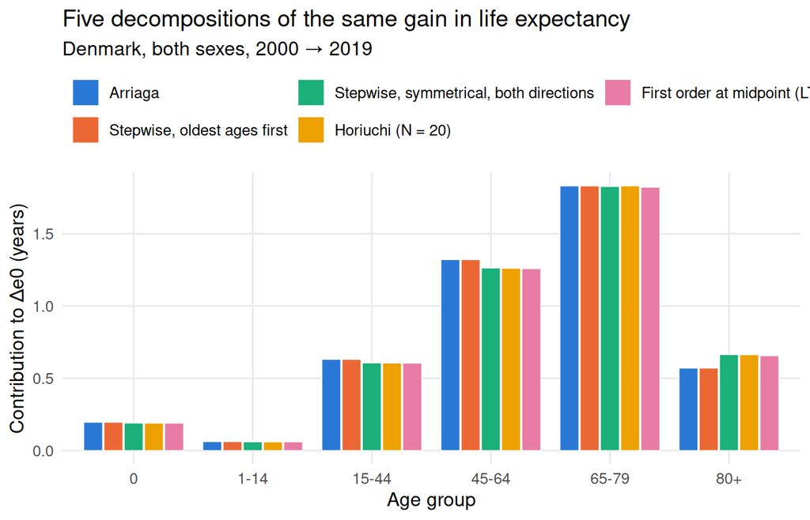

Figure 1: Contribution of age groups to the Danish e0 gain, 2000–2019, by decomposition method. Values are in the table above.

```r
pal <- c("#2a78d6", "#eb6834", "#1baf7a", "#eda100", "#e87ba4")
tl <- melt(tab[, !"total"], id.vars = "method", variable.name = "age_group")
tl[, method := factor(method, levels = names(res))]
ggplot(tl, aes(age_group, value, fill = method)) +
  geom_col(position = position_dodge(width = 0.85), width = 0.8, colour = "white", linewidth = 0.3) +
  scale_fill_manual(values = pal) +
  labs(x = "Age group", y = "Contribution to Δe0 (years)", fill = NULL,
       title = "Five decompositions of the same gain in life expectancy",
       subtitle = "Denmark, both sexes, 2000 → 2019") +
  theme_minimal(base_size = 12) +
  theme(legend.position = "top", legend.justification = "left", panel.grid.minor = element_blank()) +
  guides(fill = guide_legend(nrow = 2))
```

## Verification

Every method’s adding-up identity is tested. Each method is also checked against an independent implementation. These checks run again when this report is rendered:

```r
e0_scalar <- function(m) life_table(m)$ex[1]
ax0 <- LEdecomp::mx_to_ax(d0$mx, age = d0$age, sex = "t")
ax1 <- LEdecomp::mx_to_ax(d1$mx, age = d0$age, sex = "t")
hud <- local({ e <- new.env(); utils::data("hudsonia", package = "popbio", envir = e); e$hudsonia })
dg <- local({ e <- new.env(); utils::data("dgeg2_3", package = "DasGuptR", envir = e); e$dgeg2_3 })
fac <- c("birth_preg", "preg_actw", "actw_prop", "w_prop")
dgr <- suppressMessages(DasGuptR::dgnpop(dg, pop = "pop", factors = fac))
dg_ref <- sapply(fac, function(k) dgr$rate[dgr$factor == k & dgr$pop == 1979] - dgr$rate[dgr$factor == k & dgr$pop == 1971])
dg_ours <- das_gupta_n(as.list(dg[dg$pop == 1971, fac]), as.list(dg[dg$pop == 1979, fac]))
chk <- data.table(
  check = c("das_gupta_n() vs DasGuptR::dgnpop() (Das Gupta Ex. 2.3)",
            "arriaga_decomp() vs LEdecomp::arriaga()",
            "stepwise_decomp() vs DemoDecomp::stepwise_replacement()",
            "horiuchi_decomp() vs DemoDecomp::horiuchi()",
            "ltre_fixed() vs popbio::LTRE()"),
  max_abs_difference = c(
    max(abs(dg_ours[fac] - dg_ref)),
    max(abs(arriaga_decomp(d0$mx, d1$mx, ax1 = ax0, ax2 = ax1)$total -
            LEdecomp::arriaga(d0$mx, d1$mx, age = d0$age, sex1 = "t"))),
    max(abs(stepwise_decomp(life_expectancy, d0$mx, d1$mx, direction = "both", vectorized = TRUE) -
            DemoDecomp::stepwise_replacement(e0_scalar, d0$mx, d1$mx, direction = "both"))),
    max(abs(horiuchi_decomp(life_expectancy, d0$mx, d1$mx, N = 10, vectorized = TRUE) -
            DemoDecomp::horiuchi(e0_scalar, d0$mx, d1$mx, N = 10))),
    max(abs(unclass(ltre_fixed(hud$A85, hud$A88))[1:36] - unclass(popbio::LTRE(hud$A88, hud$A85))[1:36]))))
chk[, max_abs_difference := signif(max_abs_difference, 2)]
chk
```

| check | max_abs_difference |
| --- | --- |
| das_gupta_n() vs DasGuptR::dgnpop() (Das Gupta Ex. 2.3) | 0 |
| arriaga_decomp() vs LEdecomp::arriaga() | 0 |
| stepwise_decomp() vs DemoDecomp::stepwise_replacement() | 0 |
| horiuchi_decomp() vs DemoDecomp::horiuchi() | 0 |
| ltre_fixed() vs popbio::LTRE() | 0 |

The GVC side has its own checks. The components of all four methods sum to gross exports to 1e-8 at the country, sector and bilateral levels. Leontief domestic content equals Borin-Mancini’s `DC`. The known bias in KWW’s foreign value added shows up against BM. The original `icio` tests (`bm`, `wwz`, `leontief`, `load_icio`) still pass unchanged.

## Performance

`stepwise_decomp()` and `horiuchi_decomp()` were written to be at least as fast as the DemoDecomp originals. They are much faster when the evaluated function is vectorised:

- Every parameter set is built as a column of one matrix. With `vectorized = TRUE`, `func` is called once (stepwise) or once per block of steps (Horiuchi), instead of thousands of times.
- `life_expectancy()` computes e0 for all columns at once with `matrixStats::colCumprods()` and `colSums2()`, the same tools `icio` uses for speed.
- Horiuchi writes each half-step perturbation only into the entries of its own component, instead of adding a large, mostly-zero matrix.
- Stepwise evaluates the two end points once, not once per direction.

```r
timeit <- function(expr, reps = 3L, inner = 5L) {
  e <- substitute(expr); env <- parent.frame()
  stats::median(vapply(seq_len(reps), function(i)
    system.time(for (k in seq_len(inner)) eval(e, env))[["elapsed"]] / inner, numeric(1)))
}
data("Mxc1", package = "DemoDecomp", envir = environment()); data("Mxc2", package = "DemoDecomp", envir = environment())
age_id <- rep(seq_len(nrow(Mxc1)), ncol(Mxc1)); nx_abr <- c(1, 4, rep(5, 17))
cod_s <- function(v) life_expectancy(rowsum(v, age_id, reorder = FALSE), nx = nx_abr)
cod_v <- function(M) life_expectancy(rowsum(M, age_id, reorder = FALSE), nx = nx_abr)
q1 <- c(Mxc1); q2 <- c(Mxc2); e0s <- function(m) life_expectancy(m)
bench <- rbind(
  data.table(case = "e0, 96 ages", method = "stepwise (both, symmetrical)",
             DemoDecomp = timeit(DemoDecomp::stepwise_replacement(e0s, d0$mx, d1$mx, direction = "both")),
             ddec_vectorized = timeit(stepwise_decomp(e0s, d0$mx, d1$mx, direction = "both", vectorized = TRUE))),
  data.table(case = "e0, 96 ages", method = "Horiuchi (N = 20)",
             DemoDecomp = timeit(DemoDecomp::horiuchi(e0s, d0$mx, d1$mx, N = 20), inner = 1L),
             ddec_vectorized = timeit(horiuchi_decomp(e0s, d0$mx, d1$mx, N = 20, vectorized = TRUE))),
  data.table(case = "e0 by cause, 114 parameters", method = "stepwise (both, symmetrical)",
             DemoDecomp = timeit(DemoDecomp::stepwise_replacement(cod_s, q1, q2, direction = "both")),
             ddec_vectorized = timeit(stepwise_decomp(cod_v, q1, q2, direction = "both", vectorized = TRUE))),
  data.table(case = "e0 by cause, 114 parameters", method = "Horiuchi (N = 20)",
             DemoDecomp = timeit(DemoDecomp::horiuchi(cod_s, q1, q2, N = 20), inner = 1L),
             ddec_vectorized = timeit(horiuchi_decomp(cod_v, q1, q2, N = 20, vectorized = TRUE))))
bench[, speedup := round(DemoDecomp / ddec_vectorized, 1)]
bench[, `:=`(DemoDecomp = signif(DemoDecomp, 3), ddec_vectorized = signif(ddec_vectorized, 3))]
setnames(bench, c("DemoDecomp", "ddec_vectorized"), c("DemoDecomp (s)", "ddec, vectorized (s)"))
bench
```

| case | method | DemoDecomp (s) | ddec, vectorized (s) | speedup |
| --- | --- | --- | --- | --- |
| e0, 96 ages | stepwise (both, symmetrical) | 0.0100 | 0.0018 | 5.6 |
| e0, 96 ages | Horiuchi (N = 20) | 0.0850 | 0.0242 | 3.5 |
| e0 by cause, 114 parameters | stepwise (both, symmetrical) | 0.0168 | 0.0016 | 10.5 |
| e0 by cause, 114 parameters | Horiuchi (N = 20) | 0.1670 | 0.0062 | 26.9 |

Timings are from the machine that rendered this report. With an ordinary function that takes one parameter vector, `ddec` runs at the same speed as DemoDecomp, because calling the function is the whole cost. The full benchmark is in `misc/bench_stepwise_horiuchi.R`.

## Problems found and fixed during the work

| Problem | How it was found | Fix |
| --- | --- | --- |
| The report’s IO sensitivity used the full value-added vector while the statistic summed only country C1’s rows; the first-order error showed as −592% | checking the rendered numbers against the exact change | mask `v` and `e` to C1 before calling `leontief_sensitivity()`; noted in CLAUDE.md |
| Claim that one-directional stepwise “young to old” equals Arriaga | a test failed by 0.019 years | it is `direction = "down"` (oldest ages first) under DemoDecomp’s convention; docs and tests corrected |
| A cached Quarto `setup` chunk skipped `load_all()` on re-render | render error | setup chunks set to `cache: false` |
| popbio’s built-in matrices are not substochastic (column sums > 1) | cross-check error | test uses a valid stage matrix |
| DESCRIPTION `URL` was missing the pkgdown site address | `pkgdown::check_pkgdown()` | URL added |
| Report text overstated how closely LTRE and Shapley agree for *Hudsonia* (they differ by up to about 14% by group) | rechecking the rendered table | figure caption rewritten |

## Open items

1. **Authors.** The edited DESCRIPTION no longer lists Bastiaan Quast, Fei Wang, Victor Stolzenburg or Oliver Reiter, but their GVC code is still in the package (`wwz()` and `leontief()` credit them), and `inst/CITATION` still names Quast. GPL practice and CRAN policy both expect authors of included code to be listed.
2. **DESCRIPTION text vs the new title.** The title is now *Demographic Decomposition Methods*, but the Description still describes the trade-and-demography framing, and does not mention stepwise replacement or Horiuchi.
3. **CI has not run.** The branch is not pushed. The renv-related workflow changes will be tested by the first run.
4. **Possible next steps for the demographic focus:**
   - cause-of-death variants of Arriaga, and cause × age output for Horiuchi and stepwise (`components =` already supports grouping);
   - vectorised versions of other common outcomes (TFR, healthy life expectancy, life-table entropy);
   - HMD data as an optional source;
   - symmetrised Arriaga, for parity with LEdecomp’s `arriaga_sym()`;
   - deciding whether the GVC code stays at the core of a demography-focused package or moves to a companion package.

## References

Andreev, Evgeny M., Vladimir M. Shkolnikov, and Alexander Z. Begun. 2002. “Algorithm for Decomposition of Differences Between Aggregate Demographic Measures and Its Application to Life Expectancies, Healthy Life Expectancies, Parity-Progression Ratios and Total Fertility Rates.” *Demographic Research* 7 (14): 499–522. https://doi.org/10.4054/DemRes.2002.7.14.

Arriaga, Eduardo E. 1984. “Measuring and Explaining the Change in Life Expectancies.” *Demography* 21 (1): 83–96. https://doi.org/10.2307/2061029.

Caswell, Hal. 1989. “Analysis of Life Table Response Experiments I. Decomposition of Effects on Population Growth Rate.” *Ecological Modelling* 46 (3–4): 221–37. https://doi.org/10.1016/0304-3800(89)90019-7.

Das Gupta, Prithwis. 1993. *Standardization and Decomposition of Rates: A User’s Manual*. Current Population Reports Nos. P23-186. U.S. Bureau of the Census.

Horiuchi, Shiro, John R. Wilmoth, and Scott D. Pletcher. 2008. “A Decomposition Method Based on a Model of Continuous Change.” *Demography* 45 (4): 785–801. https://doi.org/10.1353/dem.0.0033.

Kitagawa, Evelyn M. 1955. “Components of a Difference Between Two Rates.” *Journal of the American Statistical Association* 50 (272): 1168–94. https://doi.org/10.1080/01621459.1955.10501299.

Preston, Samuel H., Patrick Heuveline, and Michel Guillot. 2001. *Demography: Measuring and Modeling Population Processes*. Blackwell.